# Analysis 07/16

D. Ford Hannum Jr.

7/16/2020

# Introduction

This is follow-up analysis to the Min Lab Meeting on 07/08/2020.

At the meeting we went over *Figure Generation v3* and discussed elements of the excel file *submk.markers.xlsx*.

# To-Do

- Reanalyze the MK subclusters and excluding the MEPs since they didn’t contribute anything to the analysis
- Do differential expression between the normal and abnormal (only show up in Mpl) subclusters
- Plot MK markers acrossthese subclusters to see if we find anything of interest
- Check Vwf complex markers (Gp1ba, Gp1bb, Gp6) which are markers of mature MKs
- Update figures and write figure legends
- Look for marker genes that identify abnormal MKs vs all other cells (for validation)
- Look into receptor ligand verification

# Reanalzying MK Subclusters

This time only including MKs (since MEPs didn’t contribute anything last time).

## UMAP Projections

The first three are interesting, but I plan on including the fourth one in the manuscript as figure 4a

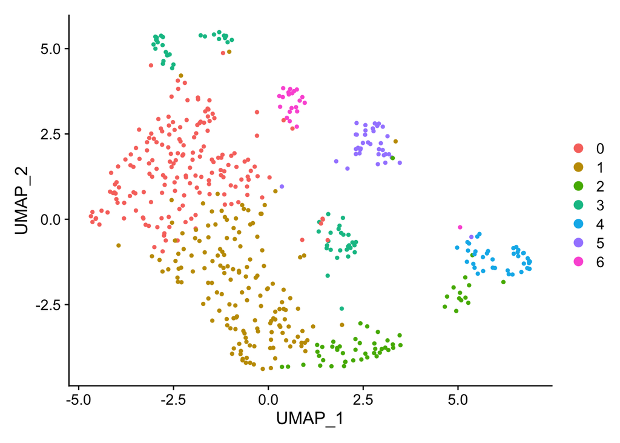

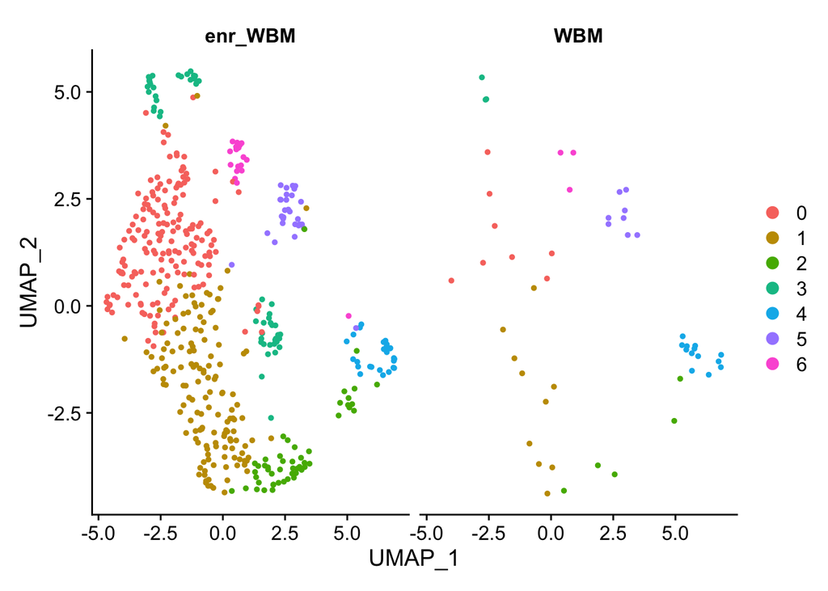

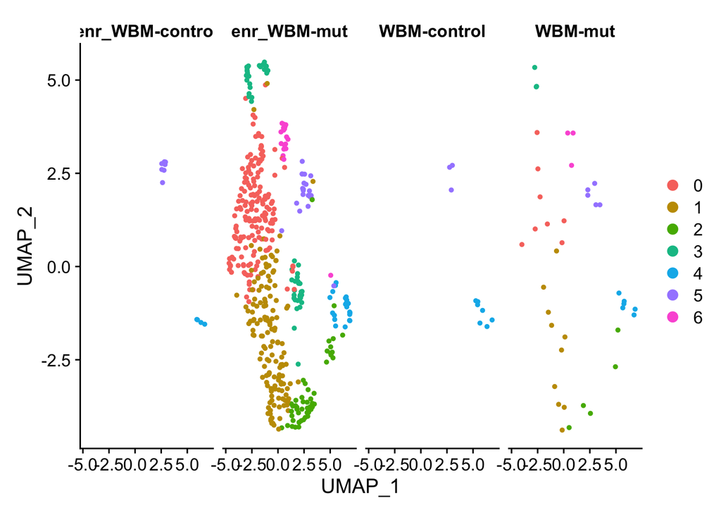

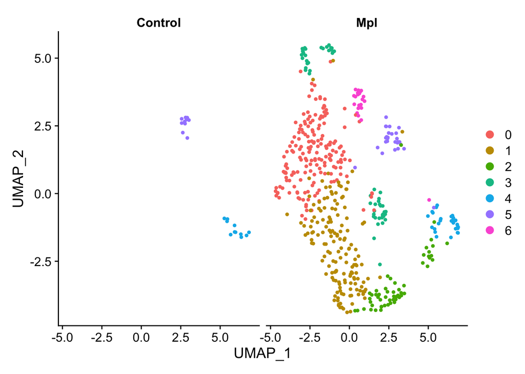

Figure Legend

UMAP Projection of the subclustering of cells identified as megakaryocytes. Subclustering identified seven clusters, with 5 of the 7 only being present in the Mpl condition.

## Table of Cluster Counts By State

```
##
##                     0   1   2   3   4   5   6
##   enr_WBM-control   0   0   0   0   4   7   0
##   enr_WBM-mut     169 146  51  52  22  22  18
##   WBM-control       0   0   0   0   7   3   0
##   WBM-mut           8  10   5   3   6   5   3
```

## Bar Chart of Condition Distributions

Maybe not completely necessary, since the UMAP projection clearly shows this. Maybe just include as a supplementary figure.

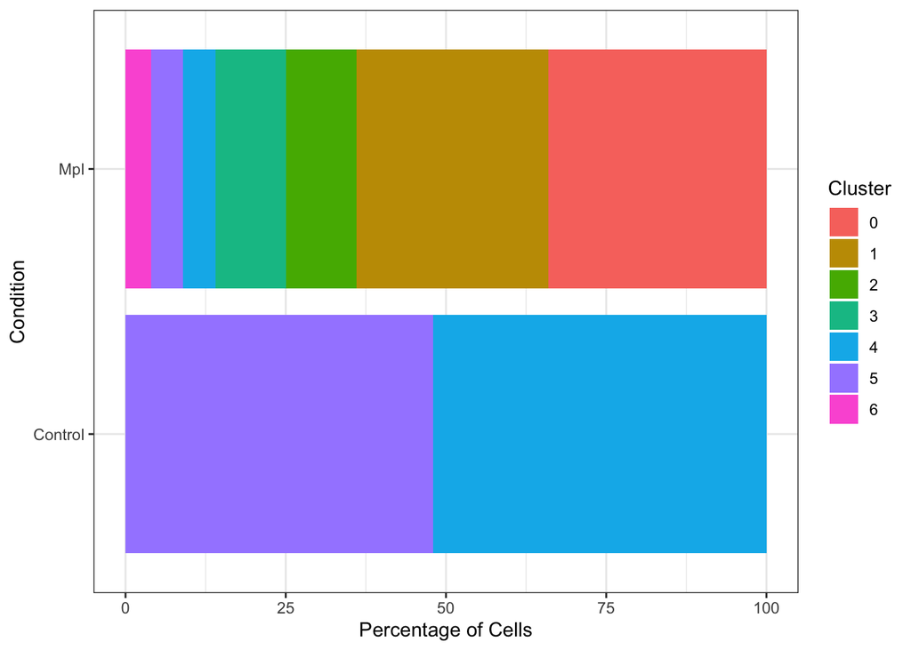

Figure Legend

The distribution of cells from each condition, each color representing a different cluster in the UMAP projection. All control cells belong to two clusters, which are also present in the Mpl condition. There are five abnormal megakaryocyte clusters that are only found in the Mpl condition.

### Bar Chart Supplemental

I was also interested in seeing how this barchart broke down into states (WBM control, enrWBM control, WBM Mpl, enrWBM Mpl), though I’m not sure it is something that would be completely necessary in the paper. What I would like to see is similar distributions between the WBM and enrWBM, when looking at either control or Mpl. If a cluster only showed up in the enrWBM I would be weary of including that for further analysis because it could potentially be an artifact of the enrichment process and not actually present in WBM.

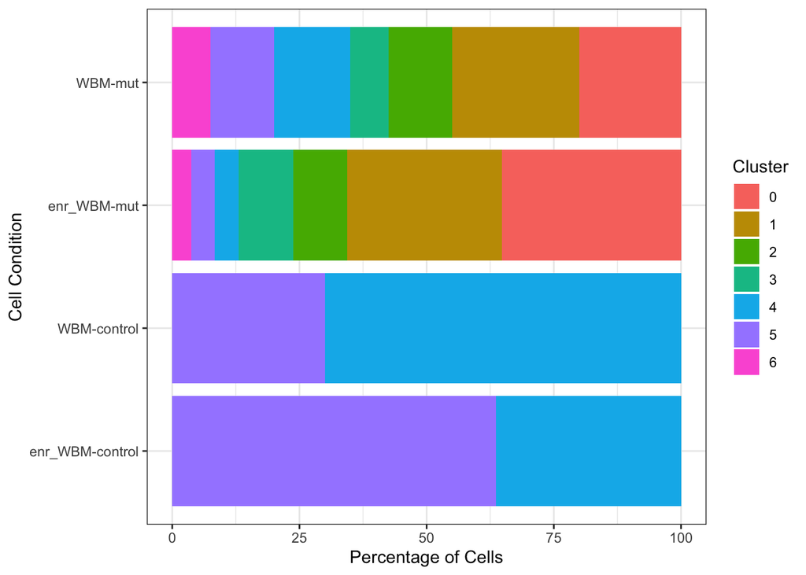

We see slightly different percentages of clusters in the distribution, but nothing I think to worry about (since the numbers in the WBM samples are so low). It’s good that we see all the clusters present in the WBM mutant (Mpl), which we could also see from one of the UMAP projections.

# Differential Expression of MK Subclusters

I’m going to approach this a few different ways:

## Comparing Abnormal as a Group vs Normal

There are 97 DE genes (adjusted p-value < 0.05) from the abnormal clusters vs the normal clusters. Group 1 is the abnormal clusters and group 2 is the normal clusters. So 30 of the genes have higher expression in the abnormal cluster, and the other 67 have higher expression in the normal cluster.

### GO Term Analysis

I put each of these gene lists through seperately using the [Princeton GO Term Finder](https://go.princeton.edu/cgi-bin/GOTermFinder).

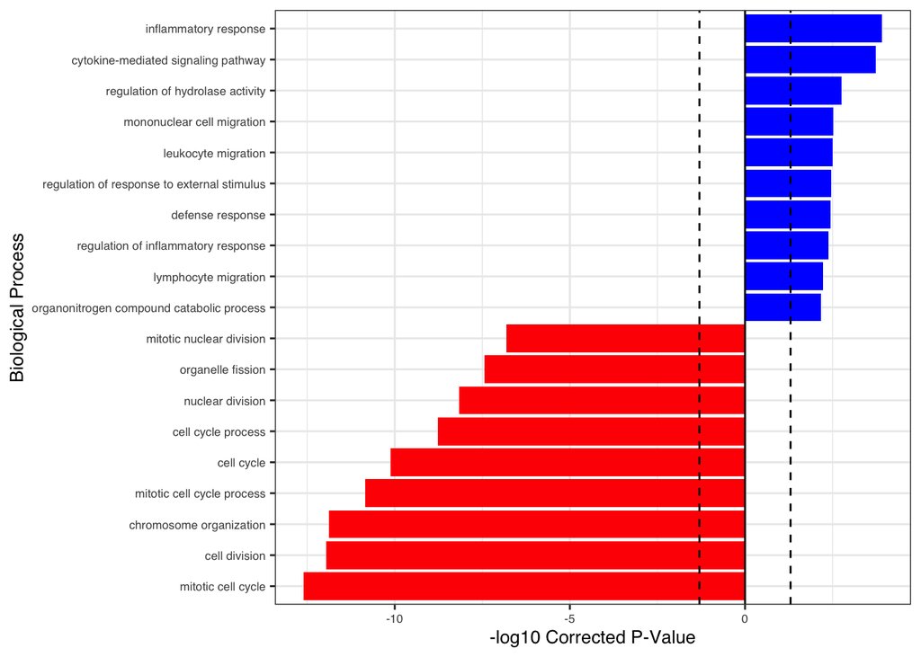

This is how I graphed previous results, but it may not be the best way. The dashed line is the cutoff for significance, and as long as the bar is passed the dashed line (which all of these are) they’re significant. ’’

# MK Marker Expression Within Subclusters

I wanted to look at our MK marker genes and their expression through the subclusters.

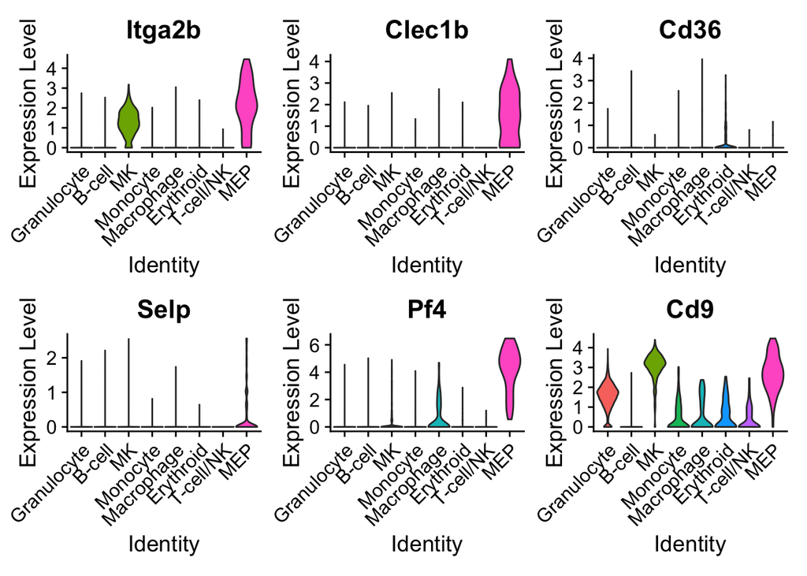

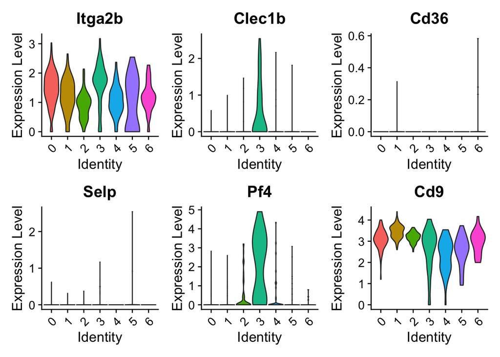

# Looking at VWF Complex

Next I wanted to look into the VWF Complex and see how the genes related to that are expressed within the megakaryocytes, since they are markers of mature megakaryocytes (?). The genes I have listed are (Gp1ba, Gp1bb, Gp6).

First I want to look at their expression in all of our cells, focus on the MK subclustering. All three genes are present in the wbm data, and in the MK subset

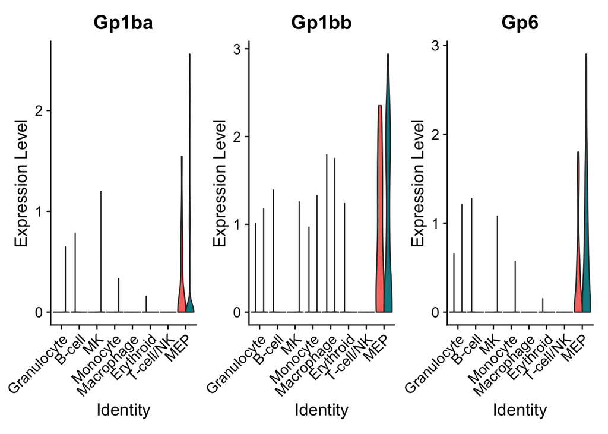

This concerns me a bit. If these are markers of mature megakarocytes we would expect them to be in the MK cluster and not in the MEP cluster, which would show MK precursurs and perhaps immature MKs. The fact we only really see them in the MEP cluster is curious.

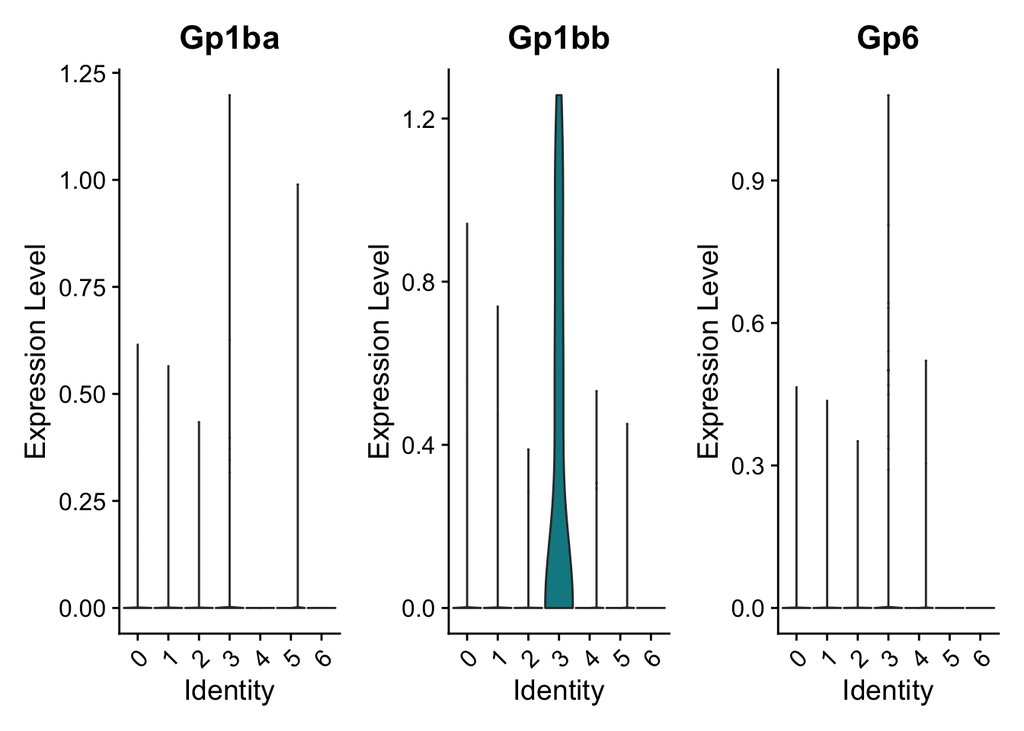

# Updating Figures and Legends

Ongoing, and for the figures in this analysis that I plan to include in the manuscript I have wrote up a figure legend.

# Abnormal MKs vs All Cells

The goal of this analysis is to potential find marker genes that distinguish these abnormal megakaryocytes from all other cells, so they can be FAC sorted. This sorting would be done on whole bone marrow, and not whole bone marrow enriched for megakaryocytes.

## In only WBM

```
##
##         enr_WBM-control enr_WBM-mut WBM-control WBM-mut
##   FALSE             606         737        2014    2299
##   TRUE                0         436           0      29
```

The above table shows cell numbers. TRUE indicates an abnormal MK cell, which we only see in the mutant condition.

```
##                p_val avg_logFC pct.1 pct.2    p_val_adj perc_diff
## Cd200r3 1.855315e-56  2.275954 1.000 0.013 5.761496e-52     0.987
## Gata2   7.786683e-59  2.342803 1.000 0.022 2.418077e-54     0.978
## F2r     2.200771e-51  1.590339 1.000 0.027 6.834274e-47     0.973
## Cyp11a1 2.134737e-77  3.162570 1.000 0.028 6.629214e-73     0.972
## Il1rl1  3.049841e-60  2.256485 1.000 0.029 9.470975e-56     0.971
## Cd200r4 9.444670e-66  1.829304 1.000 0.038 2.932948e-61     0.962
## Ccl3    4.456476e-71  3.271018 1.000 0.061 1.383914e-66     0.939
## Prss34  4.788382e-64  3.619334 1.000 0.062 1.486984e-59     0.938
## Skap1   1.083850e-37  1.332822 0.966 0.039 3.365788e-33     0.927
## Grm6    1.982470e-53  1.727276 0.931 0.011 6.156363e-49     0.920
```

I will include the whole table (nrows = 152) in a supplemental excel file. Here we see the top 10 DE genes. Of interest for us is genes with high pct.1 (percentage of abnormal MKs that express this gene) and extremely low pct.2 (percentage of all other cells that express this gene)

Keep in mind though that the number of cells in group 1 is only 29, whereas for group 2 it is 4313.

### Potential Target Genes

*Cyp11a1* ([GeneCards](https://www.genecards.org/cgi-bin/carddisp.pl?gene=CYP11A1)) looks promising as a marker for our abnormal MKs. I’m not sure what the relavence is to our study, but it shows up in 100% of abnormal MKs and only in 2.8% of the other cells.

So if Cyp11a1 was used on the combined whole bone marrow sample from controls and mutant and sorted “perfectly” we would expect to get 29 abnormal MK cells and 121 other cells (0.028 * 4313). So it isn’t that specific of a marker

*Cd200r3* ([MGI](http://www.informatics.jax.org/marker/MGI:1921853)) is another promising one with the largest percentage difference.

We would expect 29 abnormal MK cells, and 56 other cells.

*Gata2* ([GeneCards](https://www.genecards.org/cgi-bin/carddisp.pl?gene=GATA2)) is another gene, that also plays a “role in regulating transcription of genes involved in the development and proliferation of hematopoietic and endocrine cell lineages.”

We would expect 29 abnormal MK cells, and 95 other cells

**Where are the other cells coming from for these marker genes?** Could we be able to then sort these out easily?

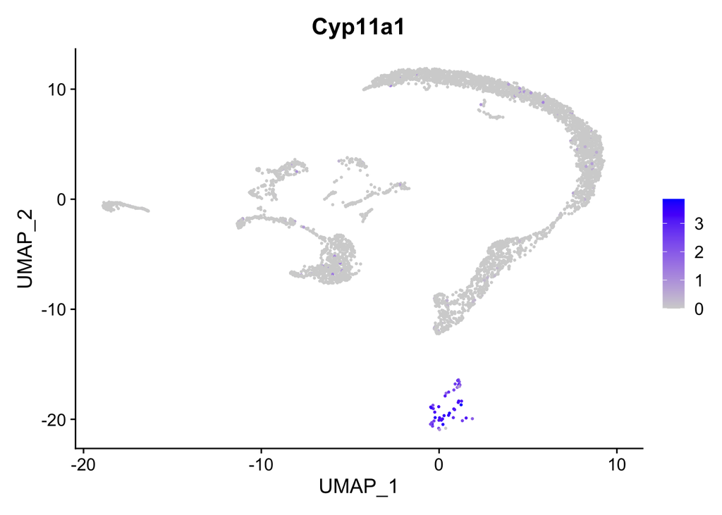

```
##
##                FALSE TRUE
##   Granulocyte1    21    0
##   Granulocyte2    11    0
##   Granulocyte3    16    0
##   B cell          10    0
##   MK              20   29
##   Granulocyte4    12    0
##   Stem Cell       10    0
##   Monocyte         4    0
##   Macrophage       3    0
##   Erythroid        1    0
##   B-cell pro       8    0
##   T-cell/NK        3    0
##   MEP              1    0
```

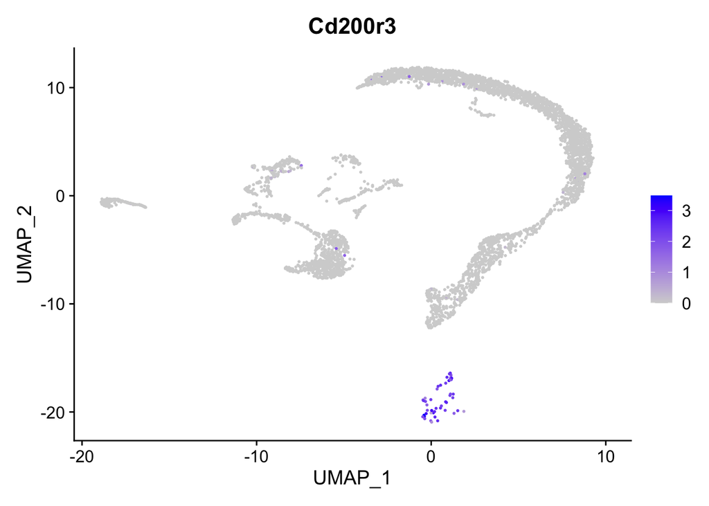

```
##
##                FALSE TRUE
##   Granulocyte1     6    0
##   Granulocyte2     6    0
##   Granulocyte3     5    0
##   B cell           2    0
##   MK              21   29
##   Granulocyte4     2    0
##   Stem Cell        3    0
##   Monocyte         8    0
##   Macrophage       0    0
##   Erythroid        0    0
##   B-cell pro       1    0
##   T-cell/NK        1    0
##   MEP              0    0
```

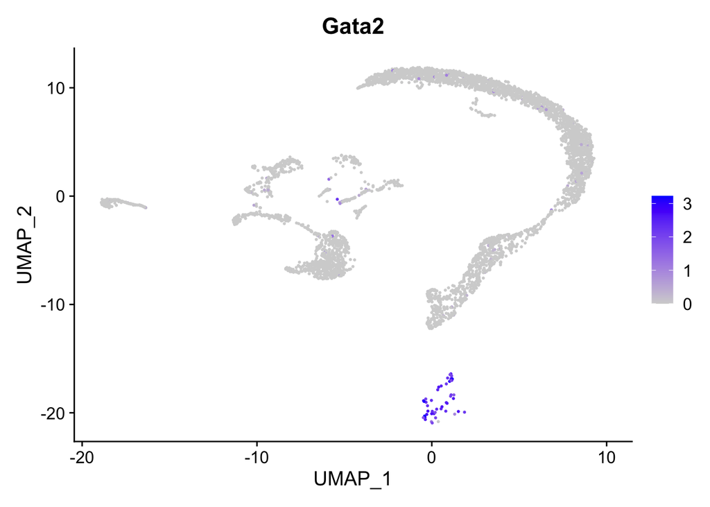

```
##
##                FALSE TRUE
##   Granulocyte1    12    0
##   Granulocyte2     8    0
##   Granulocyte3    11    0
##   B cell           7    0
##   MK              20   29
##   Granulocyte4    11    0
##   Stem Cell        7    0
##   Monocyte         6    0
##   Macrophage       0    0
##   Erythroid        8    0
##   B-cell pro       2    0
##   T-cell/NK        3    0
##   MEP              2    0
```

Figure Legend

The feature plots highlight cells that express this gene, we can see that for there feature plots it’s really only in the MK cluster where we see high expression. In the following table TRUE indicates whether or not that cell is an abnormal MK, it’s a binary quantification of the feature plot, for all the cells that have non-zero expression of the given gene.

## In WBM-mut

Keep in mind though that the number of cells in group 1 is only 29, whereas for group 2 it is 2299.

```
##                p_val avg_logFC pct.1 pct.2    p_val_adj perc_diff
## F2r     2.772123e-53  1.611166 1.000 0.013 8.608550e-49     0.987
## Cd200r3 7.411791e-56  2.291800 1.000 0.015 2.301658e-51     0.985
## Gata2   6.548878e-62  2.365956 1.000 0.023 2.033689e-57     0.977
## Il1rl1  1.942851e-55  2.249456 1.000 0.030 6.033331e-51     0.970
## Cyp11a1 3.077239e-68  3.150889 1.000 0.032 9.556059e-64     0.968
## Cd200r4 1.452881e-57  1.817033 1.000 0.046 4.511777e-53     0.954
## Skap1   1.310849e-49  1.417733 0.966 0.012 4.070710e-45     0.954
## Tmem64  5.988536e-48  1.069279 0.966 0.015 1.859680e-43     0.951
## Ccl3    4.943636e-63  3.266744 1.000 0.067 1.535197e-58     0.933
## Prss34  1.153898e-66  3.905525 1.000 0.070 3.583314e-62     0.930
```

### Potential Target Genes

*Cd200r3*

We would expect 29 abnormal MK cells, and 35 other cells.

*Gata2*

We would expect 29 abnormal MK cells, and 53 other cells.

*F2r* ([GeneCards](https://www.genecards.org/cgi-bin/carddisp.pl?gene=F2R)) showed up in the first list and is the top of this list.

We would expect 29 abnormal MK cells, and 30 other cells.

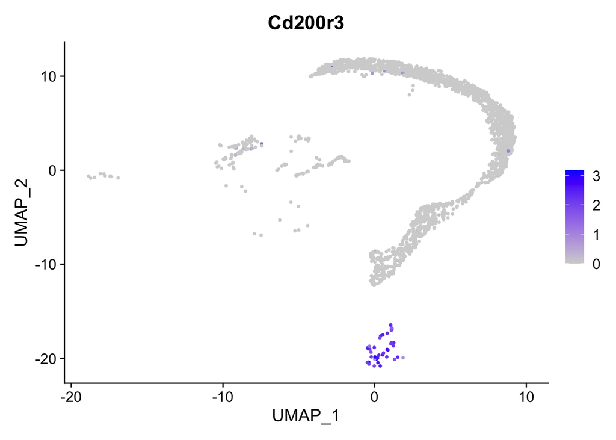

```
##
##                FALSE TRUE
##   Granulocyte1     5    0
##   Granulocyte2     4    0
##   Granulocyte3     4    0
##   B cell           0    0
##   MK              11   29
##   Granulocyte4     2    0
##   Stem Cell        2    0
##   Monocyte         7    0
##   Macrophage       0    0
##   Erythroid        0    0
##   B-cell pro       0    0
##   T-cell/NK        0    0
##   MEP              0    0
```

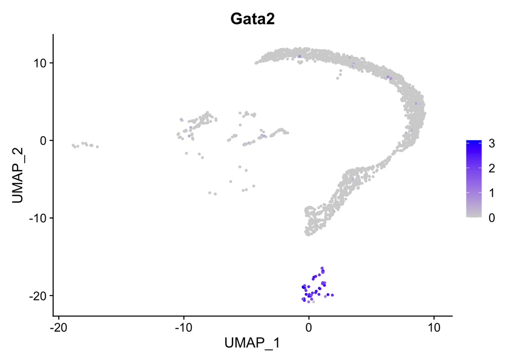

```
##
##                FALSE TRUE
##   Granulocyte1     9    0
##   Granulocyte2     5    0
##   Granulocyte3    11    0
##   B cell           0    0
##   MK              10   29
##   Granulocyte4     6    0
##   Stem Cell        4    0
##   Monocyte         3    0
##   Macrophage       0    0
##   Erythroid        4    0
##   B-cell pro       0    0
##   T-cell/NK        1    0
##   MEP              1    0
```

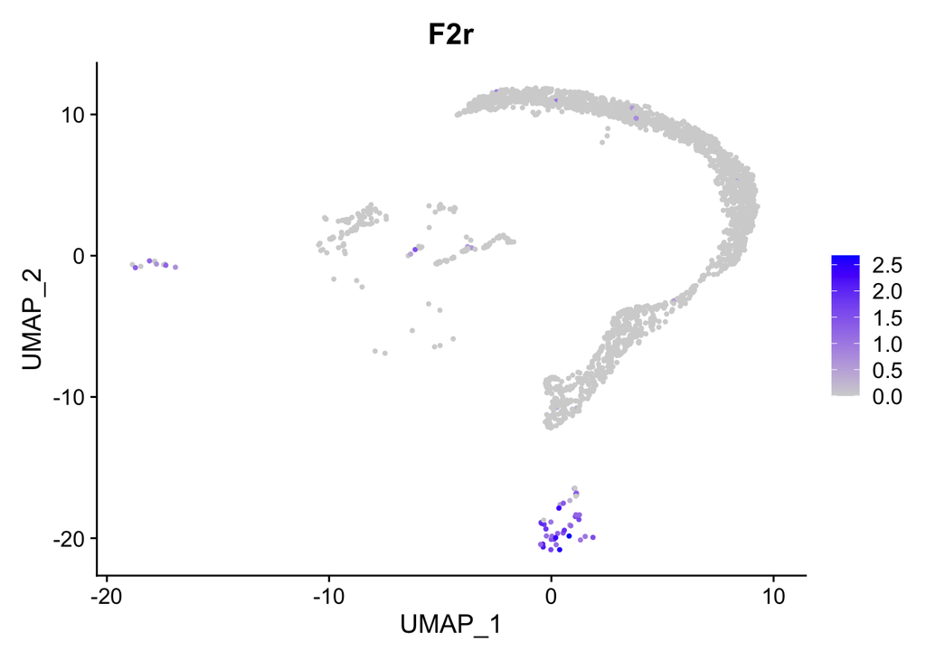

```
##
##                FALSE TRUE
##   Granulocyte1     2    0
##   Granulocyte2     3    0
##   Granulocyte3     5    0
##   B cell           0    0
##   MK               7   29
##   Granulocyte4     1    0
##   Stem Cell        2    0
##   Monocyte         0    0
##   Macrophage       0    0
##   Erythroid        3    0
##   B-cell pro       0    0
##   T-cell/NK        6    0
##   MEP              2    0
```

# Ligand Receptor Work

My lab has published a [paper](https://www.sciencedirect.com/science/article/abs/pii/S1534580720303993) on this that I am still working through.